# Sea Ice Indicators Update

##### 2021-1-15

This report presents some results of the most recent version of the algorithm for defining sea ice Freeze-up/Break-up (FUBU) dates. The NSIDC-0747 comparison plots from the previous update are included as well.

Changes since previous update:

## Freeze-up

### Definitions

#### Freeze-up start

Valid date range: 9/1 - 1/31

Threshold is set to the minimum of

1. the sum of the mean and standard deviation of daily summer sea ice concentration (SIC), and 2) 15%.
2. Freeze-up start is defined as the first day the daily SIC exceeds the threshold, unless mean summer SIC is > 25% (then, undefined).
3. Undefined if freeze-up end not defined

#### Freeze-up end

Valid date range: 9/1 - 2/28

1. Threshold is set to the maximum of 1) mean SIC in winter minus 10%, and 2) 15%.
2. Threshold is set to the minimum of this threshold and 50%
3. Freeze-up end is defined as the first day after the freeze-up start date where the daily SIC exceeds the threshold for the following two weeks  
   a. Undefined if daily SIC is above this threshold for every day of the search period.
4. Undefined if freeze-up start not defined

### Totals maps

NOTE: based on the new requirement that BOTH start/end need to be defined for either to be valid, these maps are the same.

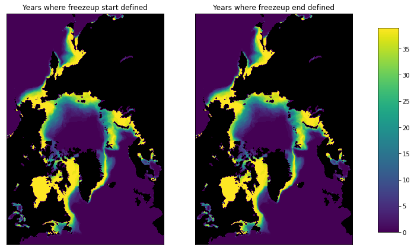

#### NSIDC-0747 results

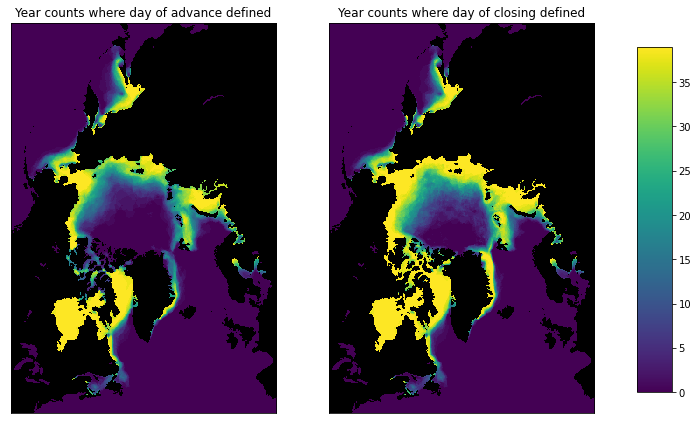

### Mean lagged-date maps

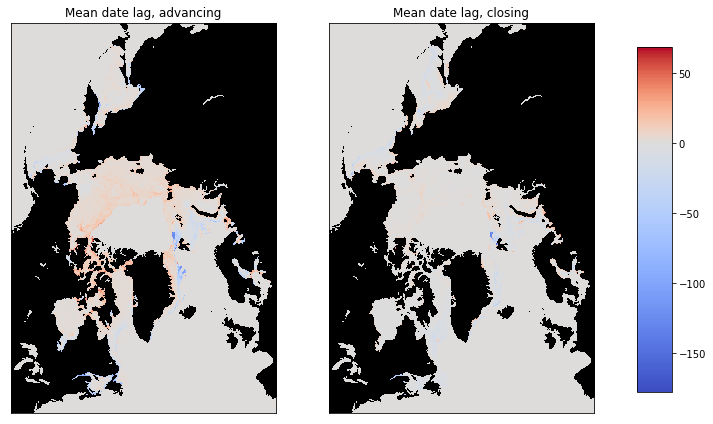

### Mean date histograms

These histograms show the mean dates for each indicator from our current algorithm (orange) along with the corresponding NSIDC-0747 indicator (blue).

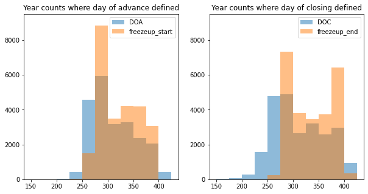

| Histogram bins (days): | 150-149 | 175-174 | 200-199 | 225-224 | 250-249 | 275-274 | 300-299 | 325-324 | 350-349 | 375-374 | 400-399 |
| --- | --- | --- | --- | --- | --- | --- | --- | --- | --- | --- | --- |
| DOA | 0.0 | 7.0 | 15.0 | 395.0 | 4561.0 | 5929.0 | 3174.0 | 3277.0 | 2379.0 | 2040.0 | 407.0 |
| freezeup_start | 0.0 | 0.0 | 0.0 | 29.0 | 1484.0 | 8846.0 | 3472.0 | 4211.0 | 4182.0 | 3064.0 | 0.0 |
| DOC | 21.0 | 73.0 | 268.0 | 1560.0 | 4794.0 | 4887.0 | 2651.0 | 3217.0 | 2566.0 | 2951.0 | 939.0 |
| freezeup_end | 0.0 | 0.0 | 0.0 | 0.0 | 240.0 | 7317.0 | 3788.0 | 3438.0 | 3744.0 | 6413.0 | 348.0 |

# Break-up

### Definitions

#### Break-up start

Valid date range: 2/1 - 7/31

1. Threshold is set to the mean winter SIC minus 2 standard deviations of the winter SIC.
2. Break-up start is defined as the last day for which previous two weeks are above this threshold if:  
   a. Mean summer SIC is less than 40%.
3. Undefined if break-up end not defined

#### Break-up end

Valid date range: 2/1 - 9/29

1. Threshold is set to the minimum of 1) the sum of the mean and standard deviation of daily summer SIC, and 2) 50%.
2. Break-up end is defined as the first day where the daily SIC is less than the threshold for the following two weeks  
   a. Undefined if daily SIC is less than this threshold for every day of the search period
3. Undefined if break-up start not defined

### Totals maps

See freeze-up totals maps note, these maps are now the same based on new requirement (#3 in each).

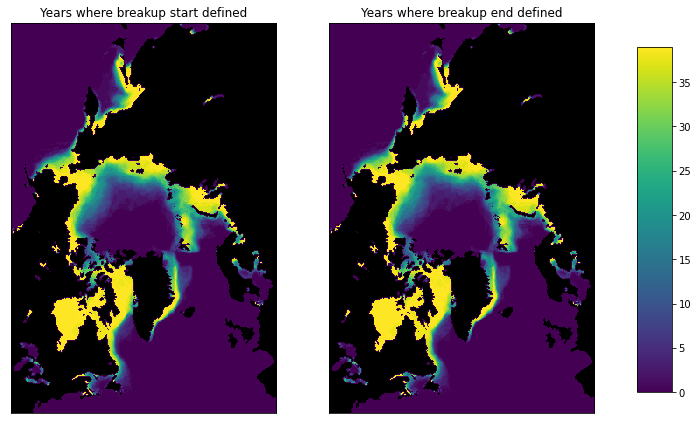

Here are the totals maps with the break-up end minimum threshold set to 60% and 35% (most recent update used %50)

#### Minimum threshold: 60%

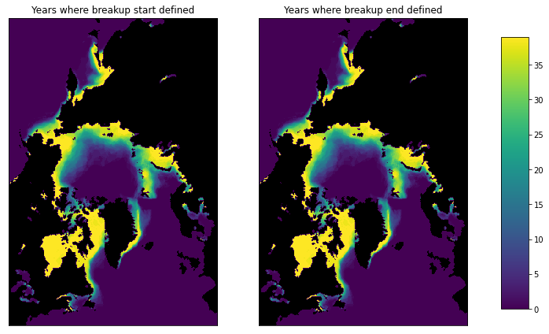

#### Minimum threshold: 35%

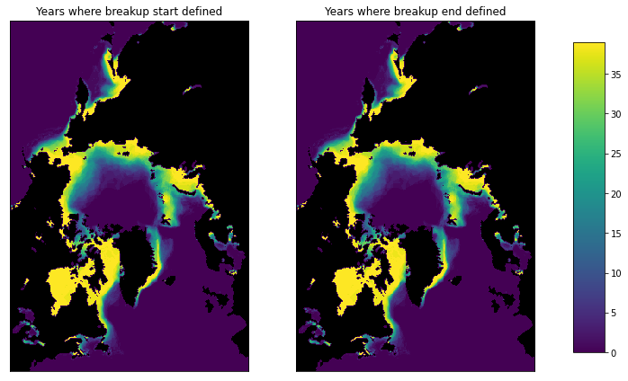

These three plots appear very similar, but they are indeed slightly different.

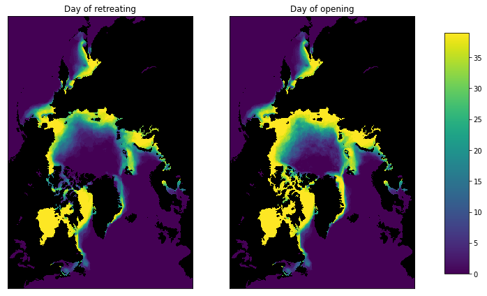

### Mean lagged-date maps

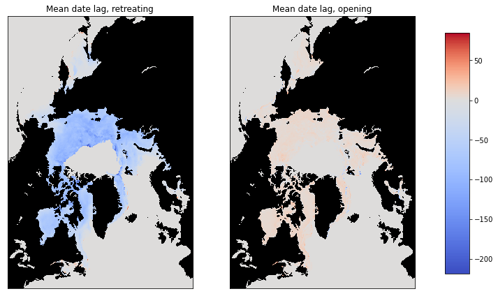

### Mean date histograms

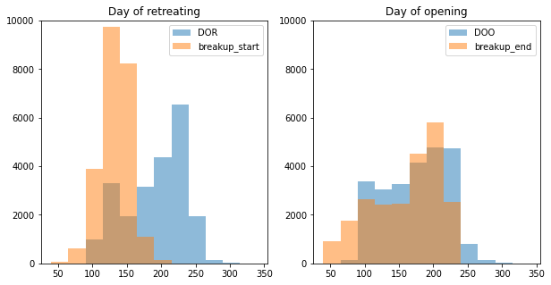

| Histogram bins (days): | 40-39 | 65-64 | 90-89 | 115-114 | 140-139 | 165-164 | 190-189 | 215-214 | 240-239 | 265-264 | 290-289 | 315-314 |
| --- | --- | --- | --- | --- | --- | --- | --- | --- | --- | --- | --- | --- |
| DOR | 0.0 | 0.0 | 974.0 | 3309.0 | 1931.0 | 3161.0 | 4387.0 | 6546.0 | 1936.0 | 150.0 | 23.0 | 0.0 |
| breakup_start | 68.0 | 619.0 | 3900.0 | 9739.0 | 8216.0 | 1108.0 | 133.0 | 0.0 | 0.0 | 0.0 | 0.0 | 0.0 |
| DOO | 0.0 | 152.0 | 3369.0 | 3064.0 | 3264.0 | 4161.0 | 4783.0 | 4735.0 | 804.0 | 133.0 | 30.0 | 0.0 |
| breakup_end | 912.0 | 1744.0 | 2643.0 | 2406.0 | 2441.0 | 4528.0 | 5808.0 | 2514.0 | 0.0 | 0.0 | 0.0 | 0.0 |

# Ice season length

These maps depict the mean length of the ice season in days (where defined), calculated as break-up end minus freeze-up start.

The plot on the right just has long historical ice seasons (means > 100) set to 0 to better highlight the shorter seasons found at the southern extent.

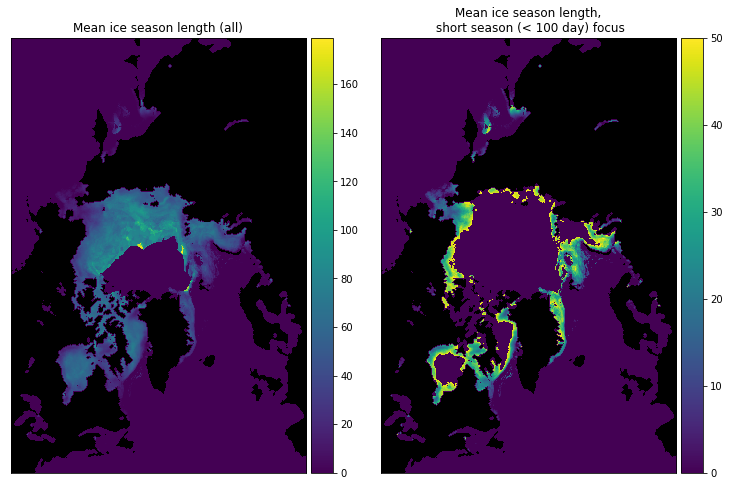

Here are the ice season length maps with the break-up end minimum threshold set to 60% and 35% (most recent update used %50).

#### Break-up end minimum threshold: 60%

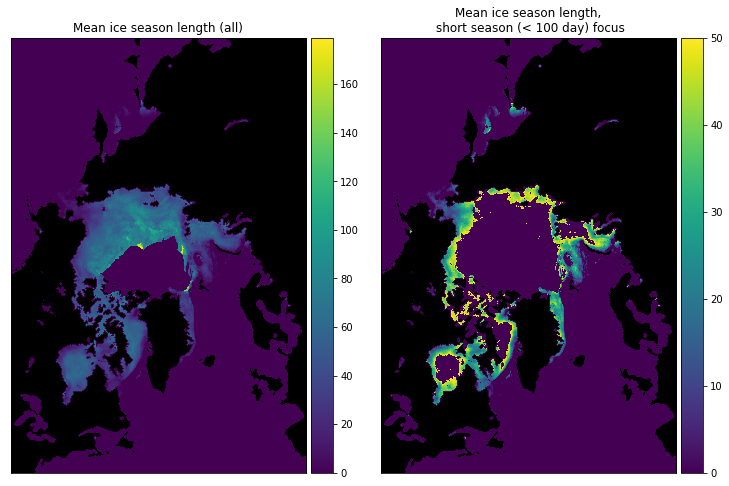

#### Break-up end minimum threshold: 35%

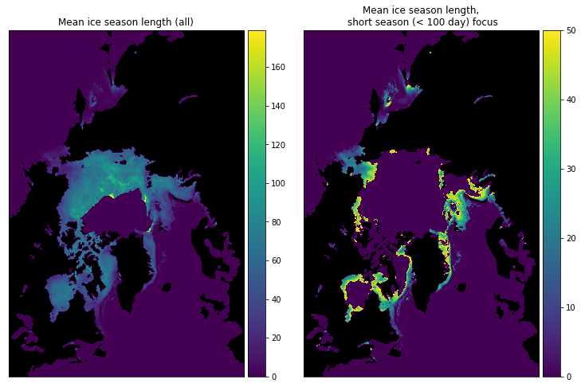